# Part 1. Reading Data

```python
# imports

import pandas as pd
import numpy as np
import matplotlib.pyplot as plt
import seaborn as sns

import random
random.seed(1)

import warnings
warnings.filterwarnings("ignore")
```

```python
# read the data

brfss_2015_dataset = pd.read_csv('diabetes_012_health_indicators_BRFSS2015.csv')
```

```python
# number of rows and columns

brfss_2015_dataset.shape
```

```
(253680, 22)
```

```python
brfss_2015_dataset
```

|  | Diabetes_012 | HighBP | HighChol | CholCheck | BMI | Smoker | Stroke | HeartDiseaseorAttack | PhysActivity | Fruits | ... | AnyHealthcare | NoDocbcCost | GenHlth | MentHlth | PhysHlth | DiffWalk | Sex | Age | Education | Income |
| --- | --- | --- | --- | --- | --- | --- | --- | --- | --- | --- | --- | --- | --- | --- | --- | --- | --- | --- | --- | --- | --- |
| 0 | 0.0 | 1.0 | 1.0 | 1.0 | 40.0 | 1.0 | 0.0 | 0.0 | 0.0 | 0.0 | ... | 1.0 | 0.0 | 5.0 | 18.0 | 15.0 | 1.0 | 0.0 | 9.0 | 4.0 | 3.0 |
| 1 | 0.0 | 0.0 | 0.0 | 0.0 | 25.0 | 1.0 | 0.0 | 0.0 | 1.0 | 0.0 | ... | 0.0 | 1.0 | 3.0 | 0.0 | 0.0 | 0.0 | 0.0 | 7.0 | 6.0 | 1.0 |
| 2 | 0.0 | 1.0 | 1.0 | 1.0 | 28.0 | 0.0 | 0.0 | 0.0 | 0.0 | 1.0 | ... | 1.0 | 1.0 | 5.0 | 30.0 | 30.0 | 1.0 | 0.0 | 9.0 | 4.0 | 8.0 |
| 3 | 0.0 | 1.0 | 0.0 | 1.0 | 27.0 | 0.0 | 0.0 | 0.0 | 1.0 | 1.0 | ... | 1.0 | 0.0 | 2.0 | 0.0 | 0.0 | 0.0 | 0.0 | 11.0 | 3.0 | 6.0 |
| 4 | 0.0 | 1.0 | 1.0 | 1.0 | 24.0 | 0.0 | 0.0 | 0.0 | 1.0 | 1.0 | ... | 1.0 | 0.0 | 2.0 | 3.0 | 0.0 | 0.0 | 0.0 | 11.0 | 5.0 | 4.0 |
| ... | ... | ... | ... | ... | ... | ... | ... | ... | ... | ... | ... | ... | ... | ... | ... | ... | ... | ... | ... | ... | ... |
| 253675 | 0.0 | 1.0 | 1.0 | 1.0 | 45.0 | 0.0 | 0.0 | 0.0 | 0.0 | 1.0 | ... | 1.0 | 0.0 | 3.0 | 0.0 | 5.0 | 0.0 | 1.0 | 5.0 | 6.0 | 7.0 |
| 253676 | 2.0 | 1.0 | 1.0 | 1.0 | 18.0 | 0.0 | 0.0 | 0.0 | 0.0 | 0.0 | ... | 1.0 | 0.0 | 4.0 | 0.0 | 0.0 | 1.0 | 0.0 | 11.0 | 2.0 | 4.0 |
| 253677 | 0.0 | 0.0 | 0.0 | 1.0 | 28.0 | 0.0 | 0.0 | 0.0 | 1.0 | 1.0 | ... | 1.0 | 0.0 | 1.0 | 0.0 | 0.0 | 0.0 | 0.0 | 2.0 | 5.0 | 2.0 |
| 253678 | 0.0 | 1.0 | 0.0 | 1.0 | 23.0 | 0.0 | 0.0 | 0.0 | 0.0 | 1.0 | ... | 1.0 | 0.0 | 3.0 | 0.0 | 0.0 | 0.0 | 1.0 | 7.0 | 5.0 | 1.0 |
| 253679 | 2.0 | 1.0 | 1.0 | 1.0 | 25.0 | 0.0 | 0.0 | 1.0 | 1.0 | 1.0 | ... | 1.0 | 0.0 | 2.0 | 0.0 | 0.0 | 0.0 | 0.0 | 9.0 | 6.0 | 2.0 |

253680 rows × 22 columns

```python
# check that the data loaded in is in the correct format

brfss_2015_dataset.head()
```

|  | Diabetes_012 | HighBP | HighChol | CholCheck | BMI | Smoker | Stroke | HeartDiseaseorAttack | PhysActivity | Fruits | ... | AnyHealthcare | NoDocbcCost | GenHlth | MentHlth | PhysHlth | DiffWalk | Sex | Age | Education | Income |
| --- | --- | --- | --- | --- | --- | --- | --- | --- | --- | --- | --- | --- | --- | --- | --- | --- | --- | --- | --- | --- | --- |
| 0 | 0.0 | 1.0 | 1.0 | 1.0 | 40.0 | 1.0 | 0.0 | 0.0 | 0.0 | 0.0 | ... | 1.0 | 0.0 | 5.0 | 18.0 | 15.0 | 1.0 | 0.0 | 9.0 | 4.0 | 3.0 |
| 1 | 0.0 | 0.0 | 0.0 | 0.0 | 25.0 | 1.0 | 0.0 | 0.0 | 1.0 | 0.0 | ... | 0.0 | 1.0 | 3.0 | 0.0 | 0.0 | 0.0 | 0.0 | 7.0 | 6.0 | 1.0 |
| 2 | 0.0 | 1.0 | 1.0 | 1.0 | 28.0 | 0.0 | 0.0 | 0.0 | 0.0 | 1.0 | ... | 1.0 | 1.0 | 5.0 | 30.0 | 30.0 | 1.0 | 0.0 | 9.0 | 4.0 | 8.0 |
| 3 | 0.0 | 1.0 | 0.0 | 1.0 | 27.0 | 0.0 | 0.0 | 0.0 | 1.0 | 1.0 | ... | 1.0 | 0.0 | 2.0 | 0.0 | 0.0 | 0.0 | 0.0 | 11.0 | 3.0 | 6.0 |
| 4 | 0.0 | 1.0 | 1.0 | 1.0 | 24.0 | 0.0 | 0.0 | 0.0 | 1.0 | 1.0 | ... | 1.0 | 0.0 | 2.0 | 3.0 | 0.0 | 0.0 | 0.0 | 11.0 | 5.0 | 4.0 |

5 rows × 22 columns

```python
# get the name of columns (features)

brfss_2015_dataset.columns
```

```
Index(['Diabetes_012', 'HighBP', 'HighChol', 'CholCheck', 'BMI', 'Smoker',
       'Stroke', 'HeartDiseaseorAttack', 'PhysActivity', 'Fruits', 'Veggies',
       'HvyAlcoholConsump', 'AnyHealthcare', 'NoDocbcCost', 'GenHlth',
       'MentHlth', 'PhysHlth', 'DiffWalk', 'Sex', 'Age', 'Education',
       'Income'],
      dtype='object')
```

# About Columns :

Diabetes_012 : you dont have diabetes, diagnosed as pre-diabetic or diabetic (0,1,2)

HighBP : Adults who have been told they have high blood pressure by a doctor, nurse, or other health professional (0,1)

HighChol : Have you EVER been told by a doctor, nurse or other health professional that your blood cholesterol is high? (0,1)

CholCheck : Cholesterol check within past five years (0,1)

BMI : Body Mass Index (BMI)

Smoker : Have you smoked at least 100 cigarettes in your entire life? [Note: 5 packs = 100 cigarettes] (0,1)

Stroke : (Ever told) you had a stroke. (0,1)

HeartDiseaseorAttack : Respondents that have ever reported having coronary heart disease (CHD) or myocardial infarction (MI) (0,1)

PhysActivity : Adults who reported doing physical activity or exercise during the past 30 days other than their regular job (0,1)

Fruits : Consume Fruit 1 or more times per day (0,1)

Veggies : Consume Vegetables 1 or more times per day (0,1)

HvyAlcoholConsump : Heavy drinkers (adult men having more than 14 drinks per week and adult women having more than 7 drinks per week)(0,1)

AnyHealthcare : Do you have any kind of health care coverage, including health insurance, prepaid plans such as HMOs, or government plans such as Medicare, or Indian Health Service? (0,1)

NoDocbcCost : Was there a time in the past 12 months when you needed to see a doctor but could not because of cost? (0,1)

GenHlth : Would you say that in general your health is: rate (1 ~ 5)

MentHlth : Now thinking about your mental health, which includes stress, depression, and problems with emotions, for how many days during the past 30 days was your mental health not good? (0 ~ 30)

PhysHlth : Now thinking about your physical health, which includes physical illness and injury, for how many days during the past 30 days was your physical health not good? (0 ~ 30)

DiffWalk : Do you have serious difficulty walking or climbing stairs? (0,1)

Sex : Indicate sex of respondent (0,1) (Female or Male)

Education : What is the highest grade or year of school you completed? (1 ~ 6)

Income : Is your annual household income from all sources: (If respondent refuses at any income level, code "Refused.") (1 ~ 8)

```python
brfss_2015_dataset.info()
```

```
<class 'pandas.core.frame.DataFrame'>
RangeIndex: 253680 entries, 0 to 253679
Data columns (total 22 columns):
 #   Column                Non-Null Count   Dtype
---  ------                --------------   -----
 0   Diabetes_012          253680 non-null  float64
 1   HighBP                253680 non-null  float64
 2   HighChol              253680 non-null  float64
 3   CholCheck             253680 non-null  float64
 4   BMI                   253680 non-null  float64
 5   Smoker                253680 non-null  float64
 6   Stroke                253680 non-null  float64
 7   HeartDiseaseorAttack  253680 non-null  float64
 8   PhysActivity          253680 non-null  float64
 9   Fruits                253680 non-null  float64
 10  Veggies               253680 non-null  float64
 11  HvyAlcoholConsump     253680 non-null  float64
 12  AnyHealthcare         253680 non-null  float64
 13  NoDocbcCost           253680 non-null  float64
 14  GenHlth               253680 non-null  float64
 15  MentHlth              253680 non-null  float64
 16  PhysHlth              253680 non-null  float64
 17  DiffWalk              253680 non-null  float64
 18  Sex                   253680 non-null  float64
 19  Age                   253680 non-null  float64
 20  Education             253680 non-null  float64
 21  Income                253680 non-null  float64
dtypes: float64(22)
memory usage: 42.6 MB
```

```python
# transform all data to integer

brfss_2015_dataset["Diabetes_012"] = brfss_2015_dataset["Diabetes_012"].astype(int)
brfss_2015_dataset["HighBP"] = brfss_2015_dataset["HighBP"].astype(int)
brfss_2015_dataset["HighChol"] = brfss_2015_dataset["HighChol"].astype(int)
brfss_2015_dataset["CholCheck"] = brfss_2015_dataset["CholCheck"].astype(int)
brfss_2015_dataset["BMI"] = brfss_2015_dataset["BMI"].astype(int)
brfss_2015_dataset["Smoker"] = brfss_2015_dataset["Smoker"].astype(int)
brfss_2015_dataset["Stroke"] = brfss_2015_dataset["Stroke"].astype(int)
brfss_2015_dataset["HeartDiseaseorAttack"] = brfss_2015_dataset["HeartDiseaseorAttack"].astype(int)
brfss_2015_dataset["PhysActivity"] = brfss_2015_dataset["PhysActivity"].astype(int)
brfss_2015_dataset["Fruits"] = brfss_2015_dataset["Fruits"].astype(int)
brfss_2015_dataset["Veggies"] = brfss_2015_dataset["Veggies"].astype(int)
brfss_2015_dataset["HvyAlcoholConsump"] = brfss_2015_dataset["HvyAlcoholConsump"].astype(int)
brfss_2015_dataset["AnyHealthcare"] = brfss_2015_dataset["AnyHealthcare"].astype(int)
brfss_2015_dataset["NoDocbcCost"] = brfss_2015_dataset["NoDocbcCost"].astype(int)
brfss_2015_dataset["GenHlth"] = brfss_2015_dataset["GenHlth"].astype(int)
brfss_2015_dataset["MentHlth"] = brfss_2015_dataset["MentHlth"].astype(int)
brfss_2015_dataset["PhysHlth"] = brfss_2015_dataset["PhysHlth"].astype(int)
brfss_2015_dataset["DiffWalk"] = brfss_2015_dataset["DiffWalk"].astype(int)
brfss_2015_dataset["Sex"] = brfss_2015_dataset["Sex"].astype(int)
brfss_2015_dataset["Age"] = brfss_2015_dataset["Age"].astype(int)
brfss_2015_dataset["Education"] = brfss_2015_dataset["Education"].astype(int)
brfss_2015_dataset["Income"] = brfss_2015_dataset["Income"].astype(int)
```

```python
brfss_2015_dataset.info()
```

```
<class 'pandas.core.frame.DataFrame'>
RangeIndex: 253680 entries, 0 to 253679
Data columns (total 22 columns):
 #   Column                Non-Null Count   Dtype
---  ------                --------------   -----
 0   Diabetes_012          253680 non-null  int32
 1   HighBP                253680 non-null  int32
 2   HighChol              253680 non-null  int32
 3   CholCheck             253680 non-null  int32
 4   BMI                   253680 non-null  int32
 5   Smoker                253680 non-null  int32
 6   Stroke                253680 non-null  int32
 7   HeartDiseaseorAttack  253680 non-null  int32
 8   PhysActivity          253680 non-null  int32
 9   Fruits                253680 non-null  int32
 10  Veggies               253680 non-null  int32
 11  HvyAlcoholConsump     253680 non-null  int32
 12  AnyHealthcare         253680 non-null  int32
 13  NoDocbcCost           253680 non-null  int32
 14  GenHlth               253680 non-null  int32
 15  MentHlth              253680 non-null  int32
 16  PhysHlth              253680 non-null  int32
 17  DiffWalk              253680 non-null  int32
 18  Sex                   253680 non-null  int32
 19  Age                   253680 non-null  int32
 20  Education             253680 non-null  int32
 21  Income                253680 non-null  int32
dtypes: int32(22)
memory usage: 21.3 MB
```

```python
# check if there is any NaN value

brfss_2015_dataset.isna().sum()
```

```
Diabetes_012            0
HighBP                  0
HighChol                0
CholCheck               0
BMI                     0
Smoker                  0
Stroke                  0
HeartDiseaseorAttack    0
PhysActivity            0
Fruits                  0
Veggies                 0
HvyAlcoholConsump       0
AnyHealthcare           0
NoDocbcCost             0
GenHlth                 0
MentHlth                0
PhysHlth                0
DiffWalk                0
Sex                     0
Age                     0
Education               0
Income                  0
dtype: int64
```

```python
# check the values of 'diabetes_012': 0 is for no diabetes ,1 is for pre-diabetes and 2 is for diabetes.

brfss_2015_dataset.Diabetes_012.unique()
```

[output not shown]

```python
# check the values of 'HighBP': 0 represents no high blood pressure and 1 represents high blood pressure.

brfss_2015_dataset.HighBP.unique()
```

[output not shown]

```python
# check the values of 'HighChol': 0 represents no high cholesterol and 1 represents high cholesterol.

brfss_2015_dataset.HighChol.unique()
```

[output not shown]

```python
# check the values of 'CholCheck': 0 represents cholesterol is Not checked in the past 5 years and 1 represents cholesterol is checked in the past 5 years .

brfss_2015_dataset.CholCheck.unique()
```

[output not shown]

```python
# check the values of 'BMI': Body Mass Index

brfss_2015_dataset.BMI.unique()
```

[output not shown]

```python
# check the values of 'Smoker': 1 for smokers and 0 for not-smokers.

brfss_2015_dataset.Smoker.unique()
```

[output not shown]

```python
# check the values of 'Stroke': 0 for not experiencing stroke and 1 for people with stroke experience.

brfss_2015_dataset.Stroke.unique()
```

[output not shown]

```python
# check the values of 'HeartDiseaseorAttack': 0 for no heart disease/attack and 1 for people with heart disease/attack.

brfss_2015_dataset.HeartDiseaseorAttack.unique()
```

[output not shown]

```python
# check the values of 'PhysActivity': 0 for no physical activity and 1 for people with physical activity.

brfss_2015_dataset.PhysActivity.unique()
```

[output not shown]

```python
# check the values of 'Fruits': 0 means no fruit consumed per day. 1 represents consumed 1 or more pieces of fruits per day.

brfss_2015_dataset.Fruits.unique()
```

[output not shown]

```python
# check the values of 'Veggies': 0 means no vegetables consumed per day. 1 represents consumed 1 or more pieces of vegetables per day.

brfss_2015_dataset.Veggies.unique()
```

[output not shown]

```python
# check the values of 'HvyAlcoholConsump': 0 means no heavy alcohol consumption and 1 represents heavy alcohol consumption.

brfss_2015_dataset.HvyAlcoholConsump.unique()
```

[output not shown]

```python
# check the values of 'AnyHealthcare': 0 means no haelth care access and 1 represents access to health care.

brfss_2015_dataset.AnyHealthcare.unique()
```

[output not shown]

```python
# check the values of 'NoDocbcCost': .

brfss_2015_dataset.NoDocbcCost.unique()
```

[output not shown]

```python
# check the values of 'GenHlth': general health condition: 1 is Excellent -> 5 is Poor.

brfss_2015_dataset.GenHlth.unique()
```

[output not shown]

```python
# check the values of 'MentHlth': mental health days.

brfss_2015_dataset.MentHlth.unique()
```

[output not shown]

```python
# check the values of 'PhysHlth': physical health days.

brfss_2015_dataset.PhysHlth.unique()
```

[output not shown]

```python
# check the values of 'DiffWalk': 1 for having serious difficulty walking or climbing stairs and 0 for no serious problem walking.

brfss_2015_dataset.DiffWalk.unique()
```

[output not shown]

```python
# check the values of 'Sex': 0 for female, 1 for male.

brfss_2015_dataset.Sex.unique()
```

[output not shown]

```python
# check the values of 'Age': 13-level age category, 1 = 18-24, 9 = 60-64, 13 = 80 or older

brfss_2015_dataset.Age.unique()
```

[output not shown]

```python
# check the values of 'Education': Education level, scale 1-6, 1 = Never attended school or only kindergarten, 2 = elementary etc.

brfss_2015_dataset.Education.unique()
```

[output not shown]

```python
# check the values of 'Income': Income scale, scale 1-8, 1 = less than $10,000, 5 = less than $35,000, 8 = $75,000 or more

brfss_2015_dataset.Income.unique()
```

[output not shown]

```python
# check the duplicated data

brfss_2015_dataset.duplicated().sum()
```

```
23899
```

```python
# drop duplicated data

brfss_2015_dataset.drop_duplicates(inplace = True)
```

```python
# check if the duplicated data is droped

print(brfss_2015_dataset.duplicated().sum())
brfss_2015_dataset.shape
```

```
0
```

```
(229781, 22)
```

```python
brfss_2015_dataset.describe().T
```

|  | count | mean | std | min | 25% | 50% | 75% | max |
| --- | --- | --- | --- | --- | --- | --- | --- | --- |
| Diabetes_012 | 229781.0 | 0.325627 | 0.724623 | 0.0 | 0.0 | 0.0 | 0.0 | 2.0 |
| HighBP | 229781.0 | 0.454441 | 0.497921 | 0.0 | 0.0 | 0.0 | 1.0 | 1.0 |
| HighChol | 229781.0 | 0.441760 | 0.496598 | 0.0 | 0.0 | 0.0 | 1.0 | 1.0 |
| CholCheck | 229781.0 | 0.959535 | 0.197047 | 0.0 | 1.0 | 1.0 | 1.0 | 1.0 |
| BMI | 229781.0 | 28.685670 | 6.786360 | 12.0 | 24.0 | 27.0 | 32.0 | 98.0 |
| Smoker | 229781.0 | 0.465661 | 0.498821 | 0.0 | 0.0 | 0.0 | 1.0 | 1.0 |
| Stroke | 229781.0 | 0.044756 | 0.206767 | 0.0 | 0.0 | 0.0 | 0.0 | 1.0 |
| HeartDiseaseorAttack | 229781.0 | 0.103216 | 0.304241 | 0.0 | 0.0 | 0.0 | 0.0 | 1.0 |
| PhysActivity | 229781.0 | 0.733355 | 0.442206 | 0.0 | 0.0 | 1.0 | 1.0 | 1.0 |
| Fruits | 229781.0 | 0.612966 | 0.487073 | 0.0 | 0.0 | 1.0 | 1.0 | 1.0 |
| Veggies | 229781.0 | 0.794813 | 0.403839 | 0.0 | 1.0 | 1.0 | 1.0 | 1.0 |
| HvyAlcoholConsump | 229781.0 | 0.060710 | 0.238798 | 0.0 | 0.0 | 0.0 | 0.0 | 1.0 |
| AnyHealthcare | 229781.0 | 0.946075 | 0.225871 | 0.0 | 1.0 | 1.0 | 1.0 | 1.0 |
| NoDocbcCost | 229781.0 | 0.092810 | 0.290167 | 0.0 | 0.0 | 0.0 | 0.0 | 1.0 |
| GenHlth | 229781.0 | 2.601151 | 1.064685 | 1.0 | 2.0 | 3.0 | 3.0 | 5.0 |
| MentHlth | 229781.0 | 3.505373 | 7.713725 | 0.0 | 0.0 | 0.0 | 2.0 | 30.0 |
| PhysHlth | 229781.0 | 4.675178 | 9.046568 | 0.0 | 0.0 | 0.0 | 4.0 | 30.0 |
| DiffWalk | 229781.0 | 0.185507 | 0.388709 | 0.0 | 0.0 | 0.0 | 0.0 | 1.0 |
| Sex | 229781.0 | 0.439231 | 0.496295 | 0.0 | 0.0 | 0.0 | 1.0 | 1.0 |
| Age | 229781.0 | 8.086582 | 3.093809 | 1.0 | 6.0 | 8.0 | 10.0 | 13.0 |
| Education | 229781.0 | 4.980568 | 0.992895 | 1.0 | 4.0 | 5.0 | 6.0 | 6.0 |
| Income | 229781.0 | 5.890383 | 2.092477 | 1.0 | 5.0 | 6.0 | 8.0 | 8.0 |

```
Diabetes_012
0    190055
1      4629
2     35097
dtype: int64
```

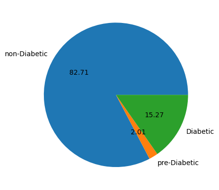

```python
# Check how many respondents have no diabetes(value = 0), prediabetes(value = 1) or diabetes(value = 2).

print(brfss_2015_dataset.groupby(['Diabetes_012']).size())
#print(brfss_2015_dataset["Diabetes_012"].value_counts())

labels=["non-Diabetic","pre-Diabetic", "Diabetic"]
# cmap = plt.get_cmap('Dark2')
# colors = cmap.colors[:len(labels)]
colors = ['#1f77b4', '#ff7f0e', '#2ca02c']

plt.pie(brfss_2015_dataset.groupby(['Diabetes_012']).size() , labels=labels ,colors=colors, autopct='%0.02f' );
```

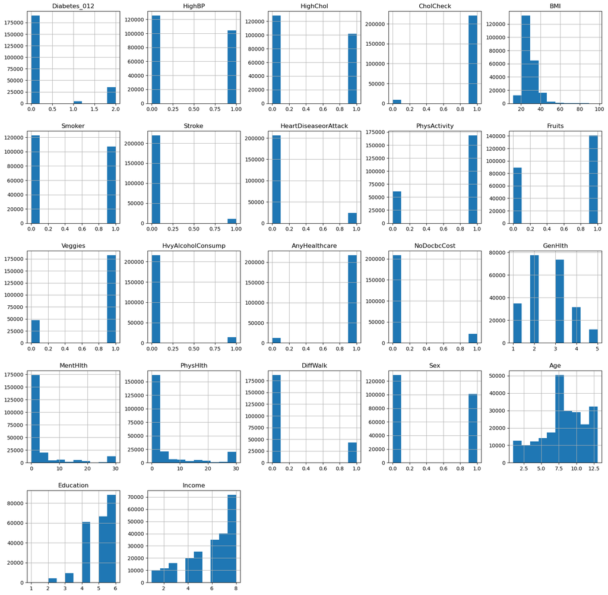

```python
# lets see how is the data distribution in different groups

histogram = brfss_2015_dataset.hist(figsize = (20,20))
```

```python
# That help us to show the relation between features clearly

brfss2 = brfss_2015_dataset.copy()

brfss2.Age[brfss2['Age'] == 1] = '18 to 24'
brfss2.Age[brfss2['Age'] == 2] = '25 to 29'
brfss2.Age[brfss2['Age'] == 3] = '30 to 34'
brfss2.Age[brfss2['Age'] == 4] = '35 to 39'
brfss2.Age[brfss2['Age'] == 5] = '40 to 44'
brfss2.Age[brfss2['Age'] == 6] = '45 to 49'
brfss2.Age[brfss2['Age'] == 7] = '50 to 54'
brfss2.Age[brfss2['Age'] == 8] = '55 to 59'
brfss2.Age[brfss2['Age'] == 9] = '60 to 64'
brfss2.Age[brfss2['Age'] == 10] = '65 to 69'
brfss2.Age[brfss2['Age'] == 11] = '70 to 74'
brfss2.Age[brfss2['Age'] == 12] = '75 to 79'
brfss2.Age[brfss2['Age'] == 13] = '80 or older'

brfss2.Diabetes_012[brfss2['Diabetes_012'] == 0] = 'No Diabetes'
brfss2.Diabetes_012[brfss2['Diabetes_012'] == 1] = 'Pre-Diabetes'
brfss2.Diabetes_012[brfss2['Diabetes_012'] == 2] = 'Diabetes'


brfss2.HighBP[brfss2['HighBP'] == 0] = 'No High BP'
brfss2.HighBP[brfss2['HighBP'] == 1] = 'High BP'

brfss2.HighChol[brfss2['HighChol'] == 0] = 'No High Chol'
brfss2.HighChol[brfss2['HighChol'] == 1] = 'High Chol'

brfss2.CholCheck[brfss2['CholCheck'] == 0] = 'No Chol Check in 5 Years'
brfss2.CholCheck[brfss2['CholCheck'] == 1] = 'Chol Check in 5 Years'

brfss2.Smoker[brfss2['Smoker'] == 0] = 'No'
brfss2.Smoker[brfss2['Smoker'] == 1] = 'Yes'

brfss2.Stroke[brfss2['Stroke'] == 0] = 'No'
brfss2.Stroke[brfss2['Stroke'] == 1] = 'Yes'

brfss2.HeartDiseaseorAttack[brfss2['HeartDiseaseorAttack'] == 0] = 'No'
brfss2.HeartDiseaseorAttack[brfss2['HeartDiseaseorAttack'] == 1] = 'Yes'

brfss2.PhysActivity[brfss2['PhysActivity'] == 0] = 'No'
brfss2.PhysActivity[brfss2['PhysActivity'] == 1] = 'Yes'

brfss2.Fruits[brfss2['Fruits'] == 0] = 'No'
brfss2.Fruits[brfss2['Fruits'] == 1] = 'Yes'

brfss2.Veggies[brfss2['Veggies'] == 0] = 'No'
brfss2.Veggies[brfss2['Veggies'] == 1] = 'Yes'

brfss2.HvyAlcoholConsump[brfss2['HvyAlcoholConsump'] == 0] = 'No'
brfss2.HvyAlcoholConsump[brfss2['HvyAlcoholConsump'] == 1] = 'Yes'

brfss2.AnyHealthcare[brfss2['AnyHealthcare'] == 0] = 'No'
brfss2.AnyHealthcare[brfss2['AnyHealthcare'] == 1] = 'Yes'

brfss2.NoDocbcCost[brfss2['NoDocbcCost'] == 0] = 'No'
brfss2.NoDocbcCost[brfss2['NoDocbcCost'] == 1] = 'Yes'

brfss2.GenHlth[brfss2['GenHlth'] == 5] = 'Excellent'
brfss2.GenHlth[brfss2['GenHlth'] == 4] = 'Very Good'
brfss2.GenHlth[brfss2['GenHlth'] == 3] = 'Good'
brfss2.GenHlth[brfss2['GenHlth'] == 2] = 'Fair'
brfss2.GenHlth[brfss2['GenHlth'] == 1] = 'Poor'

brfss2.DiffWalk[brfss2['DiffWalk'] == 0] = 'No'
brfss2.DiffWalk[brfss2['DiffWalk'] == 1] = 'Yes'

brfss2.Sex[brfss2['Sex'] == 0] = 'Female'
brfss2.Sex[brfss2['Sex'] == 1] = 'Male'

brfss2.Education[brfss2['Education'] == 1] = 'Never Attended School'
brfss2.Education[brfss2['Education'] == 2] = 'Elementary'
brfss2.Education[brfss2['Education'] == 3] = 'Junior High School'
brfss2.Education[brfss2['Education'] == 4] = 'Senior High School'
brfss2.Education[brfss2['Education'] == 5] = 'Undergraduate Degree'
brfss2.Education[brfss2['Education'] == 6] = 'Magister'

brfss2.Income[brfss2['Income'] == 1] = '< $10 K '
brfss2.Income[brfss2['Income'] == 2] = '$10-15 K'
brfss2.Income[brfss2['Income'] == 3] = '$15-20 K'
brfss2.Income[brfss2['Income'] == 4] = '$20-25 K'
brfss2.Income[brfss2['Income'] == 5] = '$25-35 K'
brfss2.Income[brfss2['Income'] == 6] = '$35-50 K'
brfss2.Income[brfss2['Income'] == 7] = '$50-75 K'
brfss2.Income[brfss2['Income'] == 8] = '> $75 K'
```

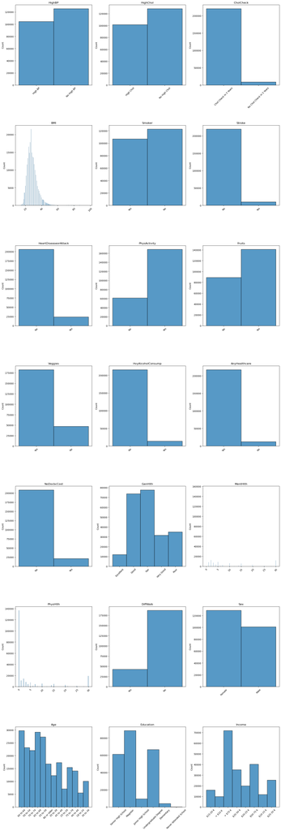

```python
# Again, lets see how is the data distribution in different groups. but with more understandable X-values

fig, axs = plt.subplots(nrows=7, ncols=3, figsize=(17, 50))

for ax, col in zip(axs.flatten(), brfss2.columns[1:]):
    sns.histplot(data=brfss2, x=col, ax=ax)
    ax.set(title=f'{col}')
    ax.set(xlabel=None)  # Remove x-label
    ax.tick_params(axis='x', rotation=45)  # Rotate x-labels

plt.tight_layout()  # Adjust spacing between subplots
plt.subplots_adjust(hspace=0.5)  # Increase vertical spacing between subplots
```

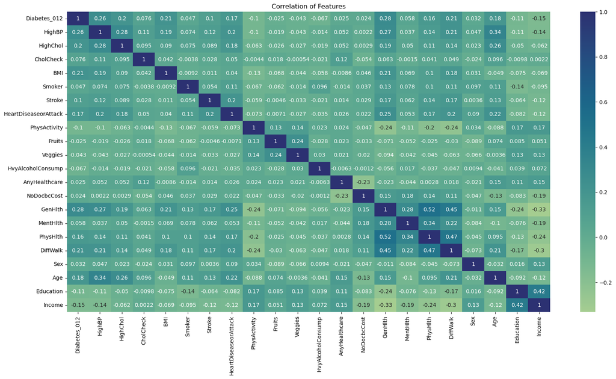

```python
#Heatmap for understanding the correlation in data

plt.figure(figsize = (20,10))
sns.heatmap(brfss_2015_dataset.corr(), annot=True, cmap ='crest')
plt.title("Correlation of Features")
```

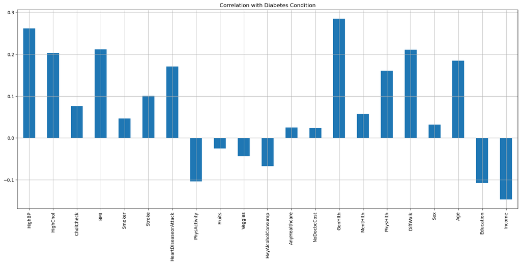

```python
#check the corellation between the attributes and the target (Diabetics_012)

brfss_2015_dataset.drop('Diabetes_012', axis=1).corrwith(brfss_2015_dataset.Diabetes_012).plot(kind='bar', grid=True, figsize=(20, 8), title="Correlation with Diabetes Condition", color='#1f77b4');
```

```python
# check the distribution of each category based on features separetaly.

#cols = ['HighBP', 'HighChol', 'BMI','Stroke', 'HeartDiseaseorAttack',
 #      'GenHlth', 'PhysHlth', 'DiffWalk', 'PhysActivity', 'Age',
  #     'Education', 'Income']

cols = brfss_2015_dataset.columns[1:]

def create_plot_pivot(brfss_2015_dataset, x_column):
    """ Create a pivot table for satisfaction versus another rating for easy plotting. """
    _df_plot = brfss_2015_dataset.groupby([x_column, 'Diabetes_012']).size() \
    .reset_index().pivot(columns='Diabetes_012', index=x_column, values=0)
    return _df_plot
```

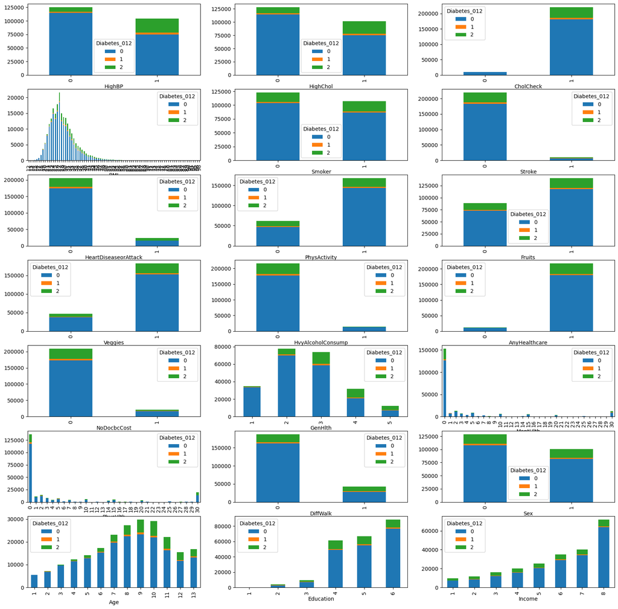

```python
fig, ax = plt.subplots(7, 3, figsize=(20,20))
axe = ax.ravel()

c = len(cols)

for i in range(c):
    create_plot_pivot(brfss_2015_dataset, cols[i]).plot(kind='bar',stacked=True, ax=axe[i])
    axe[i].set_xlabel(cols[i])

fig.show()
```

# Part 2. Creating Binary Dataset for diabetes vs. no diabetes

As the pre-diabetic group is considered to be at risk of developing diabetes, we combine the pre-diabetic and diabetic groups and refer to them as the high-risk group for diabetes, which we will call the diabetic group.

```python
# Copy old dataframe to new one.

brfss_binary = brfss_2015_dataset.copy()


# Change the value 2 to 1 to combine pre-diabetic with diabetic.

brfss_binary['Diabetes_012'] = brfss_binary['Diabetes_012'].replace({2:1})

# Change the column name to Diabetes_binary

brfss_binary = brfss_binary.rename(columns = {'Diabetes_012': 'Diabetes_01'})
brfss_binary.Diabetes_01.unique()
```

```
array([0, 1])
```

```
Diabetes_01
0    190055
1     39726
dtype: int64
```

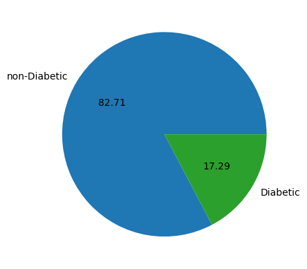

```python
# Check how many respondents have no diabetes(value = 0), or diabetes(value = 1) in the binary data.

print(brfss_binary.groupby(['Diabetes_01']).size())

labels=["non-Diabetic", "Diabetic"]
# cmap = plt.get_cmap('Dark2')
# colors = cmap.colors[:len(labels)]
colors = ['#1f77b4', '#2ca02c']

plt.pie(brfss_binary["Diabetes_01"].value_counts() , labels=labels ,colors=colors, autopct='%.02f' );
```

```python
# check the distribution of each category based on features separetaly.

#cols = ['HighBP', 'HighChol', 'BMI','Stroke', 'HeartDiseaseorAttack',
 #      'GenHlth', 'PhysHlth', 'DiffWalk', 'PhysActivity', 'Age',
  #     'Education', 'Income']

cols = brfss_binary.columns[1:]

def create_plot_pivot(brfss_binary, x_column):
    """ Create a pivot table for satisfaction versus another rating for easy plotting. """
    _df_plot = brfss_binary.groupby([x_column, 'Diabetes_01']).size() \
    .reset_index().pivot(columns='Diabetes_01', index=x_column, values=0)
    return _df_plot
```

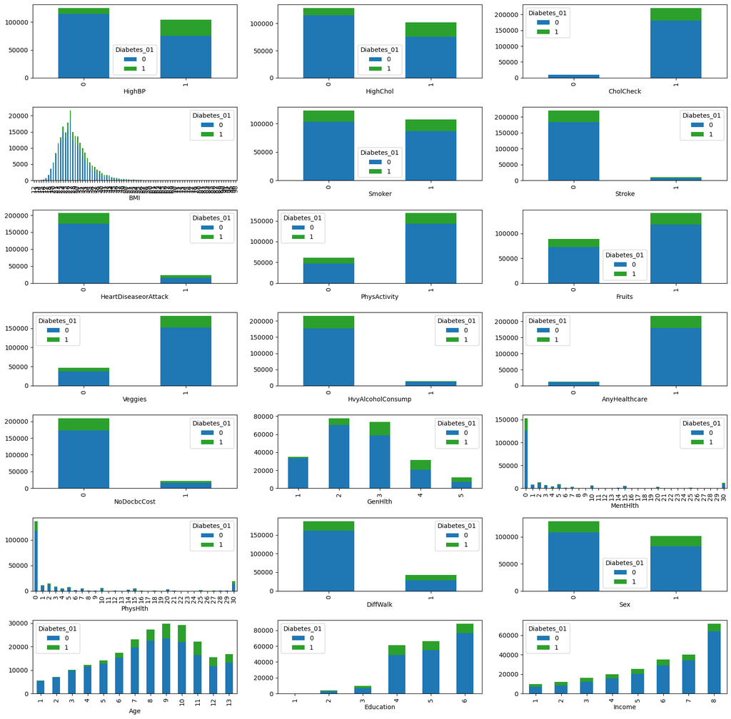

```python
fig, ax = plt.subplots(7, 3, figsize=(20,20))
axe = ax.ravel()

c = len(cols)
colors = ['#1f77b4', '#2ca02c']

for i in range(c):
    create_plot_pivot(brfss_binary, cols[i]).plot(kind='bar',stacked=True, ax=axe[i], color = colors)
    axe[i].set_xlabel(cols[i])

fig.show()
plt.subplots_adjust(hspace=0.4)  # Increase vertical spacing between subplots
```

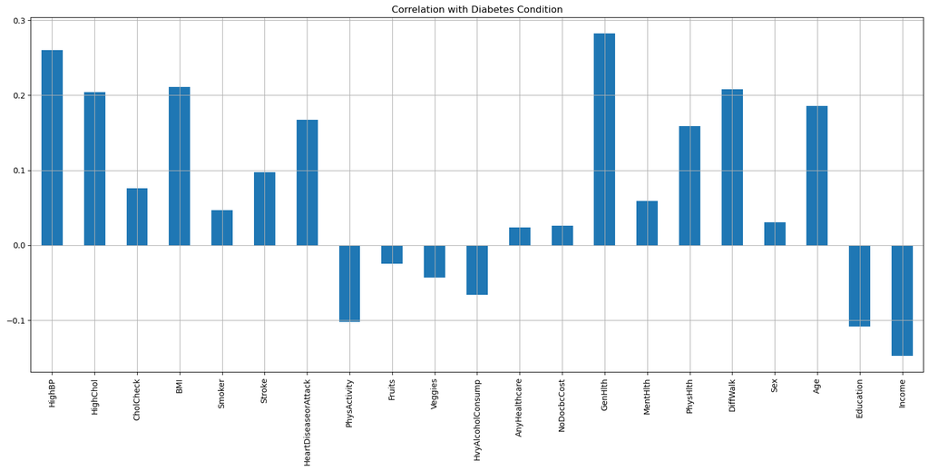

```python
#check the corellation between the attributes and the target (Diabetics_012)

brfss_binary.drop('Diabetes_01', axis=1).corrwith(brfss_binary.Diabetes_01).plot(kind='bar', grid=True, figsize=(20, 8), title="Correlation with Diabetes Condition", color='#1f77b4');
```